# Описание проекта

Вы работаете в интернет-магазине «Стримчик», который продаёт по всему миру компьютерные игры. Из открытых источников доступны исторические данные о продажах игр, оценки пользователей и экспертов, жанры и платформы (например, Xbox или PlayStation). Вам нужно выявить определяющие успешность игры закономерности. Это позволит сделать ставку на потенциально популярный продукт и спланировать рекламные кампании. Перед вами данные до 2016 года. Представим, что сейчас декабрь 2016 г., и вы планируете кампанию на 2017-й. Нужно отработать принцип работы с данными. Не важно, прогнозируете ли вы продажи на 2017 год по данным 2016-го или же 2027-й — по данным 2026 года. **Описание данных games.csv** - Name — название игры - Platform — платформа - Year_of_Release — год выпуска - Genre — жанр игры - NA_sales — продажи в Северной Америке (миллионы долларов) - EU_sales — продажи в Европе (миллионы долларов) - JP_sales — продажи в Японии (миллионы долларов) - Other_sales — продажи в других странах (миллионы долларов) - Critic_Score — оценка критиков (от 0 до 100) - User_Score — оценка пользователей (от 0 до 10) - Rating — рейтинг от организации ESRB (англ. Entertainment Software Rating Board). Эта ассоциация определяет рейтинг компьютерных игр и присваивает им подходящую возрастную категорию. Данные за 2016 год могут быть неполными.

# Шаг 2. Откройте файл с данными и изучите общую информацию

```python
import pandas as pd
import copy
import numpy as np
import scipy.stats as st
import matplotlib.pyplot as plt
import seaborn as sns
from datetime import datetime # импортирую все необходимые библиотеки сразу
df = pd.read_csv('/games.csv')
df.info()
```

```
<class 'pandas.core.frame.DataFrame'>
RangeIndex: 16715 entries, 0 to 16714
Data columns (total 11 columns):
 #   Column           Non-Null Count  Dtype
---  ------           --------------  -----
 0   Name             16713 non-null  object
 1   Platform         16715 non-null  object
 2   Year_of_Release  16446 non-null  float64
 3   Genre            16713 non-null  object
 4   NA_sales         16715 non-null  float64
 5   EU_sales         16715 non-null  float64
 6   JP_sales         16715 non-null  float64
 7   Other_sales      16715 non-null  float64
 8   Critic_Score     8137 non-null   float64
 9   User_Score       10014 non-null  object
 10  Rating           9949 non-null   object
dtypes: float64(6), object(5)
memory usage: 1.4+ MB
```

```python
df
```

|  | Name | Platform | Year_of_Release | Genre | NA_sales | EU_sales | JP_sales | Other_sales | Critic_Score | User_Score | Rating |
| --- | --- | --- | --- | --- | --- | --- | --- | --- | --- | --- | --- |
| 0 | Wii Sports | Wii | 2006.0 | Sports | 41.36 | 28.96 | 3.77 | 8.45 | 76.0 | 8 | E |
| 1 | Super Mario Bros. | NES | 1985.0 | Platform | 29.08 | 3.58 | 6.81 | 0.77 | NaN | NaN | NaN |
| 2 | Mario Kart Wii | Wii | 2008.0 | Racing | 15.68 | 12.76 | 3.79 | 3.29 | 82.0 | 8.3 | E |
| 3 | Wii Sports Resort | Wii | 2009.0 | Sports | 15.61 | 10.93 | 3.28 | 2.95 | 80.0 | 8 | E |
| 4 | Pokemon Red/Pokemon Blue | GB | 1996.0 | Role-Playing | 11.27 | 8.89 | 10.22 | 1.00 | NaN | NaN | NaN |
| ... | ... | ... | ... | ... | ... | ... | ... | ... | ... | ... | ... |
| 16710 | Samurai Warriors: Sanada Maru | PS3 | 2016.0 | Action | 0.00 | 0.00 | 0.01 | 0.00 | NaN | NaN | NaN |
| 16711 | LMA Manager 2007 | X360 | 2006.0 | Sports | 0.00 | 0.01 | 0.00 | 0.00 | NaN | NaN | NaN |
| 16712 | Haitaka no Psychedelica | PSV | 2016.0 | Adventure | 0.00 | 0.00 | 0.01 | 0.00 | NaN | NaN | NaN |
| 16713 | Spirits & Spells | GBA | 2003.0 | Platform | 0.01 | 0.00 | 0.00 | 0.00 | NaN | NaN | NaN |
| 16714 | Winning Post 8 2016 | PSV | 2016.0 | Simulation | 0.00 | 0.00 | 0.01 | 0.00 | NaN | NaN | NaN |

16715 rows × 11 columns

Проверяю данные в каждом столбце. Основательно изучаю столбцы, где есть пропуски.

```python
def check_columns(df):
    for column in df:
        print(column)
        print(df[column].unique())
check_columns(df)
```

```
Name
['Wii Sports' 'Super Mario Bros.' 'Mario Kart Wii' ...
 'Woody Woodpecker in Crazy Castle 5' 'LMA Manager 2007'
 'Haitaka no Psychedelica']
Platform
['Wii' 'NES' 'GB' 'DS' 'X360' 'PS3' 'PS2' 'SNES' 'GBA' 'PS4' '3DS' 'N64'
 'PS' 'XB' 'PC' '2600' 'PSP' 'XOne' 'WiiU' 'GC' 'GEN' 'DC' 'PSV' 'SAT'
 'SCD' 'WS' 'NG' 'TG16' '3DO' 'GG' 'PCFX']
Year_of_Release
[2006. 1985. 2008. 2009. 1996. 1989. 1984. 2005. 1999. 2007. 2010. 2013.
 2004. 1990. 1988. 2002. 2001. 2011. 1998. 2015. 2012. 2014. 1992. 1997.
 1993. 1994. 1982. 2016. 2003. 1986. 2000.   nan 1995. 1991. 1981. 1987.
 1980. 1983.]
Genre
['Sports' 'Platform' 'Racing' 'Role-Playing' 'Puzzle' 'Misc' 'Shooter'
 'Simulation' 'Action' 'Fighting' 'Adventure' 'Strategy' nan]
NA_sales
[4.136e+01 2.908e+01 1.568e+01 1.561e+01 1.127e+01 2.320e+01 1.128e+01
 1.396e+01 1.444e+01 2.693e+01 9.050e+00 9.710e+00 9.000e+00 8.920e+00
 1.500e+01 9.010e+00 7.020e+00 9.430e+00 1.278e+01 4.740e+00 6.380e+00
 1.083e+01 9.540e+00 9.660e+00 8.410e+00 6.060e+00 3.430e+00 5.510e+00
 6.850e+00 9.040e+00 5.890e+00 6.030e+00 9.700e+00 5.280e+00 4.990e+00
 8.250e+00 8.520e+00 5.540e+00 6.990e+00 6.620e+00 5.030e+00 5.990e+00
 3.960e+00 2.500e+00 7.970e+00 6.910e+00 4.340e+00 4.350e+00 3.010e+00
 6.160e+00 6.760e+00 4.020e+00 4.890e+00 2.960e+00 4.760e+00 5.010e+00
 6.730e+00 5.950e+00 3.660e+00 5.550e+00 7.040e+00 6.650e+00 3.880e+00
 5.800e+00 4.100e+00 5.930e+00 4.360e+00 5.700e+00 2.030e+00 4.400e+00
 5.050e+00 3.540e+00 1.120e+00 6.820e+00 1.750e+00 3.740e+00 1.060e+00
 2.790e+00 2.910e+00 9.900e-01 2.570e+00 2.990e+00 2.280e+00 7.280e+00
 2.760e+00 2.900e+00 2.810e+00 6.600e-01 3.780e+00 3.270e+00 3.560e+00
 5.390e+00 4.590e+00 4.810e+00 4.460e+00 3.480e+00 2.850e+00 2.530e+00
 2.980e+00 3.680e+00 3.150e+00 4.410e+00 4.120e+00 2.710e+00 2.930e+00
 3.230e+00 4.050e+00 4.150e+00 2.770e+00 3.450e+00 3.110e+00 8.400e-01
 1.660e+00 7.800e-01 2.640e+00 3.170e+00 4.980e+00 2.550e+00 3.640e+00
 3.700e+00 4.010e+00 2.470e+00 8.000e-02 3.920e+00 8.000e-01 2.450e+00
 4.470e+00 3.180e+00 2.630e+00 1.880e+00 2.410e+00 2.800e+00 6.300e-01
 2.260e+00 2.490e+00 3.570e+00 3.070e+00 2.970e+00 2.950e+00 2.540e+00
 3.280e+00 3.140e+00 4.700e-01 2.620e+00 3.210e+00 2.070e+00 2.730e+00
 1.850e+00 2.180e+00 1.740e+00 3.020e+00 1.620e+00 3.130e+00 1.920e+00
 3.330e+00 3.220e+00 2.300e+00 4.260e+00 9.700e-01 6.500e-01 1.210e+00
```

[output cut: 142 more lines]

```
 98. 96. 90. 84. 73. 74. 78. 92. 71. 72. 68. 62. 49. 67. 81. 66. 56. 79.
 70. 59. 64. 75. 60. 63. 69. 50. 25. 42. 44. 55. 48. 57. 29. 47. 65. 54.
 20. 53. 37. 38. 33. 52. 30. 32. 43. 45. 51. 40. 46. 39. 34. 35. 41. 36.
 28. 31. 27. 26. 19. 23. 24. 21. 17. 22. 13.]
User_Score
['8' nan '8.3' '8.5' '6.6' '8.4' '8.6' '7.7' '6.3' '7.4' '8.2' '9' '7.9'
 '8.1' '8.7' '7.1' '3.4' '5.3' '4.8' '3.2' '8.9' '6.4' '7.8' '7.5' '2.6'
 '7.2' '9.2' '7' '7.3' '4.3' '7.6' '5.7' '5' '9.1' '6.5' 'tbd' '8.8' '6.9'
 '9.4' '6.8' '6.1' '6.7' '5.4' '4' '4.9' '4.5' '9.3' '6.2' '4.2' '6' '3.7'
 '4.1' '5.8' '5.6' '5.5' '4.4' '4.6' '5.9' '3.9' '3.1' '2.9' '5.2' '3.3'
 '4.7' '5.1' '3.5' '2.5' '1.9' '3' '2.7' '2.2' '2' '9.5' '2.1' '3.6' '2.8'
 '1.8' '3.8' '0' '1.6' '9.6' '2.4' '1.7' '1.1' '0.3' '1.5' '0.7' '1.2'
 '2.3' '0.5' '1.3' '0.2' '0.6' '1.4' '0.9' '1' '9.7']
Rating
['E' nan 'M' 'T' 'E10+' 'K-A' 'AO' 'EC' 'RP']
```

```python
df[df['Name'].isna()]
```

|  | Name | Platform | Year_of_Release | Genre | NA_sales | EU_sales | JP_sales | Other_sales | Critic_Score | User_Score | Rating |
| --- | --- | --- | --- | --- | --- | --- | --- | --- | --- | --- | --- |
| 659 | NaN | GEN | 1993.0 | NaN | 1.78 | 0.53 | 0.00 | 0.08 | NaN | NaN | NaN |
| 14244 | NaN | GEN | 1993.0 | NaN | 0.00 | 0.00 | 0.03 | 0.00 | NaN | NaN | NaN |

```python
df[df['Year_of_Release'].isna()]
```

|  | Name | Platform | Year_of_Release | Genre | NA_sales | EU_sales | JP_sales | Other_sales | Critic_Score | User_Score | Rating |
| --- | --- | --- | --- | --- | --- | --- | --- | --- | --- | --- | --- |
| 183 | Madden NFL 2004 | PS2 | NaN | Sports | 4.26 | 0.26 | 0.01 | 0.71 | 94.0 | 8.5 | E |
| 377 | FIFA Soccer 2004 | PS2 | NaN | Sports | 0.59 | 2.36 | 0.04 | 0.51 | 84.0 | 6.4 | E |
| 456 | LEGO Batman: The Videogame | Wii | NaN | Action | 1.80 | 0.97 | 0.00 | 0.29 | 74.0 | 7.9 | E10+ |
| 475 | wwe Smackdown vs. Raw 2006 | PS2 | NaN | Fighting | 1.57 | 1.02 | 0.00 | 0.41 | NaN | NaN | NaN |
| 609 | Space Invaders | 2600 | NaN | Shooter | 2.36 | 0.14 | 0.00 | 0.03 | NaN | NaN | NaN |
| ... | ... | ... | ... | ... | ... | ... | ... | ... | ... | ... | ... |
| 16373 | PDC World Championship Darts 2008 | PSP | NaN | Sports | 0.01 | 0.00 | 0.00 | 0.00 | 43.0 | tbd | E10+ |
| 16405 | Freaky Flyers | GC | NaN | Racing | 0.01 | 0.00 | 0.00 | 0.00 | 69.0 | 6.5 | T |
| 16448 | Inversion | PC | NaN | Shooter | 0.01 | 0.00 | 0.00 | 0.00 | 59.0 | 6.7 | M |
| 16458 | Hakuouki: Shinsengumi Kitan | PS3 | NaN | Adventure | 0.01 | 0.00 | 0.00 | 0.00 | NaN | NaN | NaN |
| 16522 | Virtua Quest | GC | NaN | Role-Playing | 0.01 | 0.00 | 0.00 | 0.00 | 55.0 | 5.5 | T |

269 rows × 11 columns

```python
df[df['Genre'].isna()]
```

|  | Name | Platform | Year_of_Release | Genre | NA_sales | EU_sales | JP_sales | Other_sales | Critic_Score | User_Score | Rating |
| --- | --- | --- | --- | --- | --- | --- | --- | --- | --- | --- | --- |
| 659 | NaN | GEN | 1993.0 | NaN | 1.78 | 0.53 | 0.00 | 0.08 | NaN | NaN | NaN |
| 14244 | NaN | GEN | 1993.0 | NaN | 0.00 | 0.00 | 0.03 | 0.00 | NaN | NaN | NaN |

```python
df[df['Critic_Score'].isna()]
```

|  | Name | Platform | Year_of_Release | Genre | NA_sales | EU_sales | JP_sales | Other_sales | Critic_Score | User_Score | Rating |
| --- | --- | --- | --- | --- | --- | --- | --- | --- | --- | --- | --- |
| 1 | Super Mario Bros. | NES | 1985.0 | Platform | 29.08 | 3.58 | 6.81 | 0.77 | NaN | NaN | NaN |
| 4 | Pokemon Red/Pokemon Blue | GB | 1996.0 | Role-Playing | 11.27 | 8.89 | 10.22 | 1.00 | NaN | NaN | NaN |
| 5 | Tetris | GB | 1989.0 | Puzzle | 23.20 | 2.26 | 4.22 | 0.58 | NaN | NaN | NaN |
| 9 | Duck Hunt | NES | 1984.0 | Shooter | 26.93 | 0.63 | 0.28 | 0.47 | NaN | NaN | NaN |
| 10 | Nintendogs | DS | 2005.0 | Simulation | 9.05 | 10.95 | 1.93 | 2.74 | NaN | NaN | NaN |
| ... | ... | ... | ... | ... | ... | ... | ... | ... | ... | ... | ... |
| 16710 | Samurai Warriors: Sanada Maru | PS3 | 2016.0 | Action | 0.00 | 0.00 | 0.01 | 0.00 | NaN | NaN | NaN |
| 16711 | LMA Manager 2007 | X360 | 2006.0 | Sports | 0.00 | 0.01 | 0.00 | 0.00 | NaN | NaN | NaN |
| 16712 | Haitaka no Psychedelica | PSV | 2016.0 | Adventure | 0.00 | 0.00 | 0.01 | 0.00 | NaN | NaN | NaN |
| 16713 | Spirits & Spells | GBA | 2003.0 | Platform | 0.01 | 0.00 | 0.00 | 0.00 | NaN | NaN | NaN |
| 16714 | Winning Post 8 2016 | PSV | 2016.0 | Simulation | 0.00 | 0.00 | 0.01 | 0.00 | NaN | NaN | NaN |

8578 rows × 11 columns

```python
df[df['User_Score'].isna()]
```

|  | Name | Platform | Year_of_Release | Genre | NA_sales | EU_sales | JP_sales | Other_sales | Critic_Score | User_Score | Rating |
| --- | --- | --- | --- | --- | --- | --- | --- | --- | --- | --- | --- |
| 1 | Super Mario Bros. | NES | 1985.0 | Platform | 29.08 | 3.58 | 6.81 | 0.77 | NaN | NaN | NaN |
| 4 | Pokemon Red/Pokemon Blue | GB | 1996.0 | Role-Playing | 11.27 | 8.89 | 10.22 | 1.00 | NaN | NaN | NaN |
| 5 | Tetris | GB | 1989.0 | Puzzle | 23.20 | 2.26 | 4.22 | 0.58 | NaN | NaN | NaN |
| 9 | Duck Hunt | NES | 1984.0 | Shooter | 26.93 | 0.63 | 0.28 | 0.47 | NaN | NaN | NaN |
| 10 | Nintendogs | DS | 2005.0 | Simulation | 9.05 | 10.95 | 1.93 | 2.74 | NaN | NaN | NaN |
| ... | ... | ... | ... | ... | ... | ... | ... | ... | ... | ... | ... |
| 16710 | Samurai Warriors: Sanada Maru | PS3 | 2016.0 | Action | 0.00 | 0.00 | 0.01 | 0.00 | NaN | NaN | NaN |
| 16711 | LMA Manager 2007 | X360 | 2006.0 | Sports | 0.00 | 0.01 | 0.00 | 0.00 | NaN | NaN | NaN |
| 16712 | Haitaka no Psychedelica | PSV | 2016.0 | Adventure | 0.00 | 0.00 | 0.01 | 0.00 | NaN | NaN | NaN |
| 16713 | Spirits & Spells | GBA | 2003.0 | Platform | 0.01 | 0.00 | 0.00 | 0.00 | NaN | NaN | NaN |
| 16714 | Winning Post 8 2016 | PSV | 2016.0 | Simulation | 0.00 | 0.00 | 0.01 | 0.00 | NaN | NaN | NaN |

6701 rows × 11 columns

```python
df[df['Rating'].isna()]
```

|  | Name | Platform | Year_of_Release | Genre | NA_sales | EU_sales | JP_sales | Other_sales | Critic_Score | User_Score | Rating |
| --- | --- | --- | --- | --- | --- | --- | --- | --- | --- | --- | --- |
| 1 | Super Mario Bros. | NES | 1985.0 | Platform | 29.08 | 3.58 | 6.81 | 0.77 | NaN | NaN | NaN |
| 4 | Pokemon Red/Pokemon Blue | GB | 1996.0 | Role-Playing | 11.27 | 8.89 | 10.22 | 1.00 | NaN | NaN | NaN |
| 5 | Tetris | GB | 1989.0 | Puzzle | 23.20 | 2.26 | 4.22 | 0.58 | NaN | NaN | NaN |
| 9 | Duck Hunt | NES | 1984.0 | Shooter | 26.93 | 0.63 | 0.28 | 0.47 | NaN | NaN | NaN |
| 10 | Nintendogs | DS | 2005.0 | Simulation | 9.05 | 10.95 | 1.93 | 2.74 | NaN | NaN | NaN |
| ... | ... | ... | ... | ... | ... | ... | ... | ... | ... | ... | ... |
| 16710 | Samurai Warriors: Sanada Maru | PS3 | 2016.0 | Action | 0.00 | 0.00 | 0.01 | 0.00 | NaN | NaN | NaN |
| 16711 | LMA Manager 2007 | X360 | 2006.0 | Sports | 0.00 | 0.01 | 0.00 | 0.00 | NaN | NaN | NaN |
| 16712 | Haitaka no Psychedelica | PSV | 2016.0 | Adventure | 0.00 | 0.00 | 0.01 | 0.00 | NaN | NaN | NaN |
| 16713 | Spirits & Spells | GBA | 2003.0 | Platform | 0.01 | 0.00 | 0.00 | 0.00 | NaN | NaN | NaN |
| 16714 | Winning Post 8 2016 | PSV | 2016.0 | Simulation | 0.00 | 0.00 | 0.01 | 0.00 | NaN | NaN | NaN |

6766 rows × 11 columns

# Выводы:

Названия столбцов в датафрейме записаны в верхнем регистре.

Категориальные переменные: Name, Platform, Genre, Rating. Количественные переменные: Year_of_Release, NA_sales, EU_sales, JP_sales, Other_sales, Critic_Score, User_Score.

В данных присутствуют пропуски в столбцах: Name, Year_of_Release, Genre, Critic_Score, User_Score, Rating. Большое количество значений NaN в трех последних столбцах.

Тип данных был определен неверно в следующих столбцах: Year_of_release, User_score.

# Шаг 3. Подготовьте данные

Привожу названия столбцов к нижнему регистру.

```python
df.columns = df.columns.str.lower()

print(df.head())
```

```
                       name platform  year_of_release         genre  na_sales  \
0                Wii Sports      Wii           2006.0        Sports     41.36
1         Super Mario Bros.      NES           1985.0      Platform     29.08
2            Mario Kart Wii      Wii           2008.0        Racing     15.68
3         Wii Sports Resort      Wii           2009.0        Sports     15.61
4  Pokemon Red/Pokemon Blue       GB           1996.0  Role-Playing     11.27

   eu_sales  jp_sales  other_sales  critic_score user_score rating
0     28.96      3.77         8.45          76.0          8      E
1      3.58      6.81         0.77           NaN        NaN    NaN
2     12.76      3.79         3.29          82.0        8.3      E
3     10.93      3.28         2.95          80.0          8      E
4      8.89     10.22         1.00           NaN        NaN    NaN
```

Преобразую данные в нужные типы в столбцах Year_of_release (float64, а должен быть int64, т.к год - это целое число), User_score (object, а должен быть float64, т.к. оценка пользователей - это количественная переменная).

Прежде, чем поменять тип в столбце User_score, необходимо убрать значения 'tbd'. Для этого я использую параметр 'errors ='coerce' метода to_numeric, который принудительно заменит некорректные значения на NaN. Это позволит не удалять строки и продолжить работу с Датафреймом

```python
df['user_score'] = pd.to_numeric(df['user_score'], errors='coerce')
```

Данные в строках с NaN не стоит заменять на 0, т.к. это может привести к некорректным результатам статистического анализа. Удалять строки с пустыми данными во всех колонках, на мой взгляд, также нельзя. Данные отсутствуют в своем большистве всего лишь в 3 столбцах, а в 8 - они полноценные. Удалив такое кол-во строк, мы сильно исказим информацию, например, о данных по продажам или платформе.

Поэтому почистим строки только в 3х колонках с именем, жанром и годом релиза, т.к. строки без этих данных нам не пригодятся в анализе и восстановить их нельзя. Из 16715 строк удалим 271, т.е 2% от общего количества.

```python
df.dropna(subset=['name', 'genre', 'year_of_release'], inplace=True)
df['year_of_release'] = df['year_of_release'].astype(np.int64)
df.info()
```

```
<class 'pandas.core.frame.DataFrame'>
Int64Index: 16444 entries, 0 to 16714
Data columns (total 11 columns):
 #   Column           Non-Null Count  Dtype
---  ------           --------------  -----
 0   name             16444 non-null  object
 1   platform         16444 non-null  object
 2   year_of_release  16444 non-null  int64
 3   genre            16444 non-null  object
 4   na_sales         16444 non-null  float64
 5   eu_sales         16444 non-null  float64
 6   jp_sales         16444 non-null  float64
 7   other_sales      16444 non-null  float64
 8   critic_score     7983 non-null   float64
 9   user_score       7463 non-null   float64
 10  rating           9768 non-null   object
dtypes: float64(6), int64(1), object(4)
memory usage: 1.5+ MB
```

```python
genre_list = df['genre'].unique()
genre_dict = {}
for genre in genre_list:
    print(genre)
    rating_value_counts = df[df['genre'] == genre]['rating'].value_counts()
    print(rating_value_counts)
    genre_dict[genre] = rating_value_counts.index[0]

genre_dict
```

```
Sports
E       1162
T        195
E10+     105
M         16
Name: rating, dtype: int64
Platform
E       354
E10+    141
T        63
M         3
Name: rating, dtype: int64
Racing
E       576
T       167
E10+     95
M        18
Name: rating, dtype: int64
Role-Playing
T       415
M       161
E10+    111
E        83
Name: rating, dtype: int64
Puzzle
E       284
E10+     42
T        10
Name: rating, dtype: int64
Misc
E       449
T       228
E10+    166
M        13
EC        5
K-A       1
Name: rating, dtype: int64
Shooter
M       553
T       340
```

[output cut: 23 more lines]

```
Adventure
E       159
T       114
M        98
E10+     67
EC        2
Name: rating, dtype: int64
Strategy
T       160
E10+     76
E        68
M        25
K-A       2
RP        1
Name: rating, dtype: int64
```

```
{'Sports': 'E',
 'Platform': 'E',
 'Racing': 'E',
 'Role-Playing': 'T',
 'Puzzle': 'E',
 'Misc': 'E',
 'Shooter': 'M',
 'Simulation': 'E',
 'Action': 'T',
 'Fighting': 'T',
 'Adventure': 'E',
 'Strategy': 'T'}
```

```python
df['rating'] = df['rating'].fillna('NR')

def fill_rating(row):
    if row[10] == 'NR':
        row[10] = genre_dict[row[3]]
    return row

df = df.apply(fill_rating, axis=1)
df.info()
```

```
<class 'pandas.core.frame.DataFrame'>
Int64Index: 16444 entries, 0 to 16714
Data columns (total 11 columns):
 #   Column           Non-Null Count  Dtype
---  ------           --------------  -----
 0   name             16444 non-null  object
 1   platform         16444 non-null  object
 2   year_of_release  16444 non-null  int64
 3   genre            16444 non-null  object
 4   na_sales         16444 non-null  float64
 5   eu_sales         16444 non-null  float64
 6   jp_sales         16444 non-null  float64
 7   other_sales      16444 non-null  float64
 8   critic_score     7983 non-null   float64
 9   user_score       7463 non-null   float64
 10  rating           16444 non-null  object
dtypes: float64(6), int64(1), object(4)
memory usage: 1.5+ MB
```

```python
df['rating'].value_counts()
```

```
E       7679
T       5523
M       1836
E10+    1393
EC         8
K-A        3
AO         1
RP         1
Name: rating, dtype: int64
```

Посчитаю суммарные продажи во всех регионах и добавлю их в отдельный столбец total_sales.

```python
df['total_sales'] = df['na_sales'] + df['eu_sales'] + df['jp_sales'] + df['other_sales']
print(df.head())
```

```
                       name platform  year_of_release         genre  na_sales  \
0                Wii Sports      Wii             2006        Sports     41.36
1         Super Mario Bros.      NES             1985      Platform     29.08
2            Mario Kart Wii      Wii             2008        Racing     15.68
3         Wii Sports Resort      Wii             2009        Sports     15.61
4  Pokemon Red/Pokemon Blue       GB             1996  Role-Playing     11.27

   eu_sales  jp_sales  other_sales  critic_score  user_score rating  \
0     28.96      3.77         8.45          76.0         8.0      E
1      3.58      6.81         0.77           NaN         NaN      E
2     12.76      3.79         3.29          82.0         8.3      E
3     10.93      3.28         2.95          80.0         8.0      E
4      8.89     10.22         1.00           NaN         NaN      T

   total_sales
0        82.54
1        40.24
2        35.52
3        32.77
4        31.38
```

# Выводы:

Данные подготовлены к исследовательскому анализу: 1) Названия столбцов приведены к нижнему регистру; 2) Восстановлены пропуски в строках; 3) Удалено минимальное кол-во строк, где отсутствовали необходимые данные для анализа; 4) Добавлен столбец суммарных продаж.

# Шаг 4. Проведите исследовательский анализ данных

**Вопрос 1.** *Посмотрите, сколько игр выпускалось в разные годы. Важны ли данные за все периоды?*

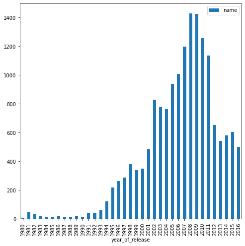

```python
df_by_year = df.pivot_table(index = 'year_of_release', values = 'name', aggfunc = 'count')
df_by_year.plot(kind='bar', figsize=(8, 8))
```

**Вывод:** С 1980 по 1993 гг. было мало компаний и выпускалось мало игр. Объем выпуска игр начинает активно расти с 1994 года. Наибольшее количество игр было выпущено с 2008 по 2009 гг. Далее с 2010 года объем выпуска игр начал снижаться. Задача исследования "выявить определяющие успешность игры закономерности", поэтому для нас будут малоинформативны данные с 1980 по 1993 гг. Т.к. в тот период была низкая конкуренция, и игровая индустрия не была так развита.

**Вопрос 2.** *Посмотрите, как менялись продажи по платформам. Выберите платформы с наибольшими суммарными продажами и постройте распределение по годам. Найдите популярные в прошлом платформы, у которых сейчас продажи на нуле. За какой характерный период появляются новые и исчезают старые платформы?*

|  | total_sales |
| --- | --- |
| count | 6.000000 |
| mean | 924.613333 |
| std | 174.136778 |
| min | 727.580000 |
| 25% | 824.880000 |
| 50% | 911.260000 |
| 75% | 953.765000 |
| max | 1233.560000 |

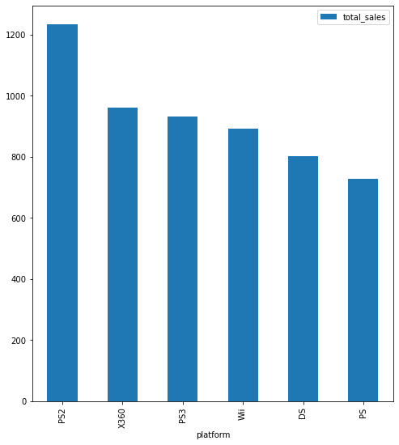

```python
platform_grouped = df.pivot_table(index='platform', values='total_sales', aggfunc='sum').sort_values(
    by='total_sales', ascending=False)
platform_grouped = platform_grouped.head(6).reset_index()
platform_grouped.plot( x='platform', y='total_sales', kind='bar', figsize=(8, 9))
top_platforms_dict = platform_grouped['platform'].unique() #создадим словарь наиболее прибыльных платформ
platform_grouped.describe()
```

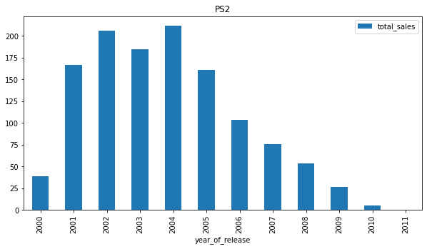

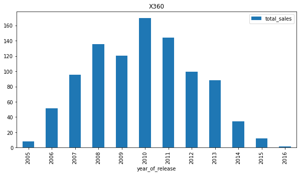

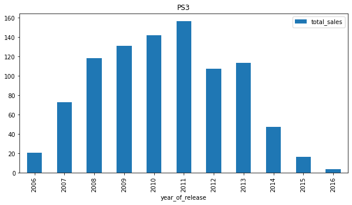

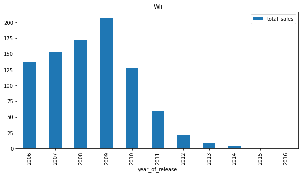

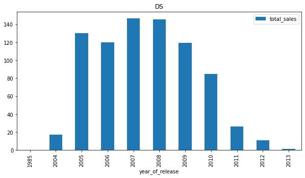

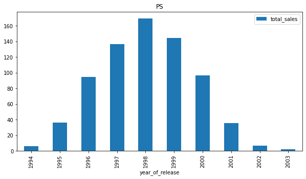

```python
#распределение продаж по годам для наиболее прибыльных платформ

for platform in top_platforms_dict:
    df[df['platform'] == platform].pivot_table(index='year_of_release', values='total_sales', aggfunc= 'sum').plot(kind='bar', figsize=(10,5))
    plt.title(platform)
```

**Вывод:** Самые прибыльные по суммарным продажам оказались платформы: PS2, X360, PS3, Wii, DS, PS. У этих же платформ к 2016 году практически нулевые продажи, т.к. их сменили новые поколения, например, платформы PS2 и PS3 сменила PS4. Из графиков видим, что срок жизни популярных игр в среднем составляет около 10 лет.

**Вопрос 3.** *Определите, данные за какой период нужно взять, чтобы исключить значимое искажение распределения по платформам в 2016 году. Далее работайте только с данными, которые вы определили. Не учитывайте данные за предыдущие годы.*

```python
actual_data = df.query('year_of_release > 2012')
actual_data.head().sort_values(by='year_of_release')
```

|  | name | platform | year_of_release | genre | na_sales | eu_sales | jp_sales | other_sales | critic_score | user_score | rating | total_sales |
| --- | --- | --- | --- | --- | --- | --- | --- | --- | --- | --- | --- | --- |
| 16 | Grand Theft Auto V | PS3 | 2013 | Action | 7.02 | 9.09 | 0.98 | 3.96 | 97.0 | 8.2 | M | 21.05 |
| 23 | Grand Theft Auto V | X360 | 2013 | Action | 9.66 | 5.14 | 0.06 | 1.41 | 97.0 | 8.1 | M | 16.27 |
| 33 | Pokemon X/Pokemon Y | 3DS | 2013 | Role-Playing | 5.28 | 4.19 | 4.35 | 0.78 | NaN | NaN | T | 14.60 |
| 42 | Grand Theft Auto V | PS4 | 2014 | Action | 3.96 | 6.31 | 0.38 | 1.97 | 97.0 | 8.3 | M | 12.62 |
| 31 | Call of Duty: Black Ops 3 | PS4 | 2015 | Shooter | 6.03 | 5.86 | 0.36 | 2.38 | NaN | NaN | M | 14.63 |

**Вывод:** Можно предположить, что в 2012 произошел кризис (почти в половину снизилось кол-во выпускаемых игр), или смена парадигмы в производстве игр. Упор сменился с объема выпускаемых игр на их качество. Поэтому актуальным периодом для дальнейшего анализа считаю 2013 - 2016 год.

**Вопрос 4.** *Какие платформы лидируют по продажам, растут или падают? Выберите несколько потенциально прибыльных платформ.*

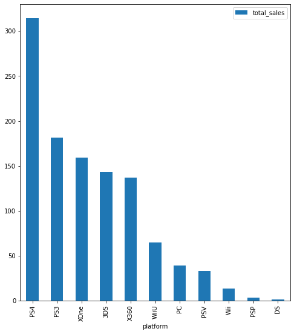

```python
platform_sales = actual_data.pivot_table(index='platform', values='total_sales', aggfunc='sum').sort_values(
    by='total_sales', ascending=False).plot(kind='bar', figsize=(8, 9))
```

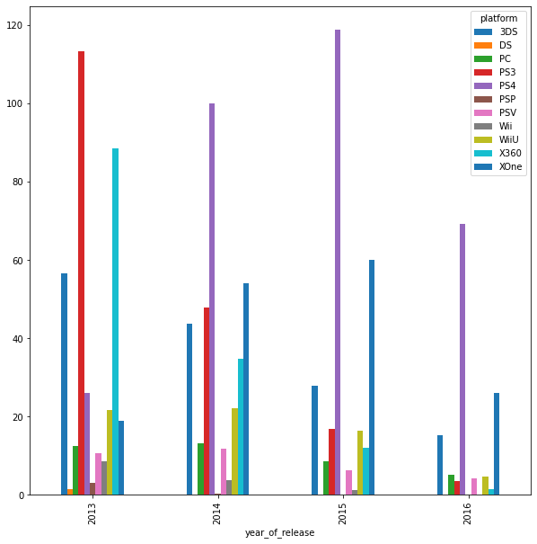

```python
platform_sales_by_year = actual_data.pivot_table(index='year_of_release', columns = 'platform', values='total_sales',
                                        aggfunc='sum').plot(kind='bar', figsize=(10,10), style=dict)
```

**Вопрос 5.** *Постройте график «ящик с усами» по глобальным продажам каждой игры и разбивкой по платформам. Велика ли разница в продажах? А в средних продажах на разных платформах? Опишите результат.*

```
count    2233.000000
mean        0.488442
std         1.235226
min         0.010000
25%         0.030000
50%         0.110000
75%         0.400000
max        21.050000
Name: total_sales, dtype: float64
```

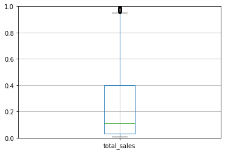

```python
actual_data.boxplot(column = 'total_sales')
plt.ylim(0,1,25)
actual_data['total_sales'].describe()
```

```
count    392.000000
mean       0.801378
std        1.609456
min        0.010000
25%        0.060000
50%        0.200000
75%        0.730000
max       14.630000
Name: total_sales, dtype: float64
```

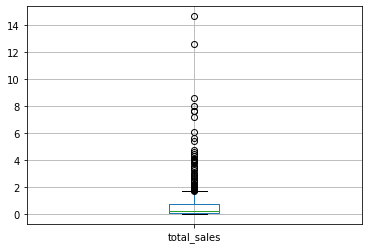

```python
PS4_actual_data = actual_data.query('platform =="PS4"')
PS4_actual_data.boxplot(column = 'total_sales')
PS4_actual_data['total_sales'].describe()
```

```
count    345.000000
mean       0.525884
std        1.451939
min        0.010000
25%        0.040000
50%        0.150000
75%        0.510000
max       21.050000
Name: total_sales, dtype: float64
```

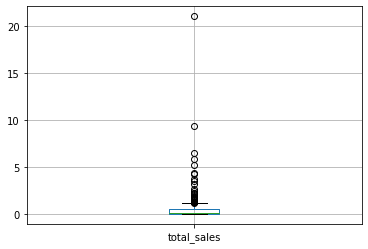

```python
PS3_actual_data = actual_data.query('platform =="PS3"')
PS3_actual_data.boxplot(column = 'total_sales')
PS3_actual_data['total_sales'].describe()
```

```
count    247.000000
mean       0.645020
std        1.036139
min        0.010000
25%        0.060000
50%        0.220000
75%        0.685000
max        7.390000
Name: total_sales, dtype: float64
```

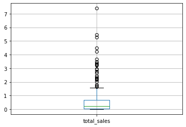

```python
XOne_actual_data = actual_data.query('platform =="XOne"')
XOne_actual_data.boxplot(column = 'total_sales')
XOne_actual_data['total_sales'].describe()
```

```
count    186.000000
mean       0.735484
std        1.663275
min        0.010000
25%        0.080000
50%        0.265000
75%        0.795000
max       16.270000
Name: total_sales, dtype: float64
```

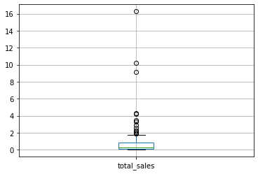

```python
X360_actual_data = actual_data.query('platform =="X360"')
X360_actual_data.boxplot(column = 'total_sales')
X360_actual_data['total_sales'].describe()
```

```
count    303.000000
mean       0.472772
std        1.381347
min        0.010000
25%        0.040000
50%        0.090000
75%        0.280000
max       14.600000
Name: total_sales, dtype: float64
```

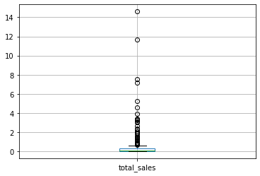

```python
_3DS_actual_data = actual_data.query('platform =="3DS"')
_3DS_actual_data.boxplot(column = 'total_sales')
_3DS_actual_data['total_sales'].describe()
```

**Вопрос 6.** *Посмотрите, как влияют на продажи внутри одной популярной платформы отзывы пользователей и критиков. Постройте диаграмму рассеяния и посчитайте корреляцию между отзывами и продажами. Сформулируйте выводы и соотнесите их с продажами игр на других платформах.*

```python
PS4_sales_crit_and_user_ratings = PS4_actual_data.loc[:,['total_sales', 'critic_score', 'user_score']]
PS4_sales_crit_and_user_ratings.head()
```

|  | total_sales | critic_score | user_score |
| --- | --- | --- | --- |
| 31 | 14.63 | NaN | NaN |
| 42 | 12.62 | 97.0 | 8.3 |
| 77 | 8.58 | 82.0 | 4.3 |
| 87 | 7.98 | NaN | NaN |
| 92 | 7.66 | 83.0 | 5.7 |

```
array([[<AxesSubplot:xlabel='total_sales', ylabel='total_sales'>,
        <AxesSubplot:xlabel='critic_score', ylabel='total_sales'>,
        <AxesSubplot:xlabel='user_score', ylabel='total_sales'>],
       [<AxesSubplot:xlabel='total_sales', ylabel='critic_score'>,
        <AxesSubplot:xlabel='critic_score', ylabel='critic_score'>,
        <AxesSubplot:xlabel='user_score', ylabel='critic_score'>],
       [<AxesSubplot:xlabel='total_sales', ylabel='user_score'>,
        <AxesSubplot:xlabel='critic_score', ylabel='user_score'>,
        <AxesSubplot:xlabel='user_score', ylabel='user_score'>]],
      dtype=object)
```

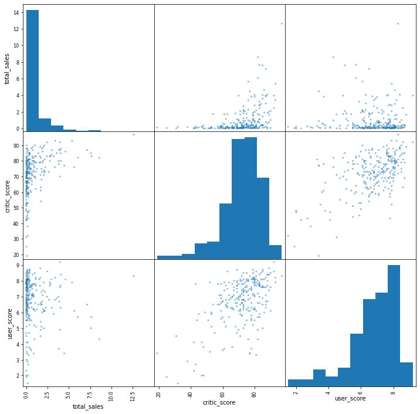

```python
pd.plotting.scatter_matrix(PS4_sales_crit_and_user_ratings, figsize=(12, 12))
```

```python
PS4_sales_crit_and_user_ratings.corr()
```

|  | total_sales | critic_score | user_score |
| --- | --- | --- | --- |
| total_sales | 1.000000 | 0.406568 | -0.031957 |
| critic_score | 0.406568 | 1.000000 | 0.557654 |
| user_score | -0.031957 | 0.557654 | 1.000000 |

```python
PS3_sales_crit_and_user_ratings = PS3_actual_data.loc[:,['total_sales', 'critic_score', 'user_score']]
PS3_sales_crit_and_user_ratings.head()
```

|  | total_sales | critic_score | user_score |
| --- | --- | --- | --- |
| 16 | 21.05 | 97.0 | 8.2 |
| 69 | 9.36 | 71.0 | 2.6 |
| 126 | 6.46 | 86.0 | 4.3 |
| 149 | 5.86 | 95.0 | 9.1 |
| 180 | 5.27 | NaN | NaN |

```
array([[<AxesSubplot:xlabel='total_sales', ylabel='total_sales'>,
        <AxesSubplot:xlabel='critic_score', ylabel='total_sales'>,
        <AxesSubplot:xlabel='user_score', ylabel='total_sales'>],
       [<AxesSubplot:xlabel='total_sales', ylabel='critic_score'>,
        <AxesSubplot:xlabel='critic_score', ylabel='critic_score'>,
        <AxesSubplot:xlabel='user_score', ylabel='critic_score'>],
       [<AxesSubplot:xlabel='total_sales', ylabel='user_score'>,
        <AxesSubplot:xlabel='critic_score', ylabel='user_score'>,
        <AxesSubplot:xlabel='user_score', ylabel='user_score'>]],
      dtype=object)
```

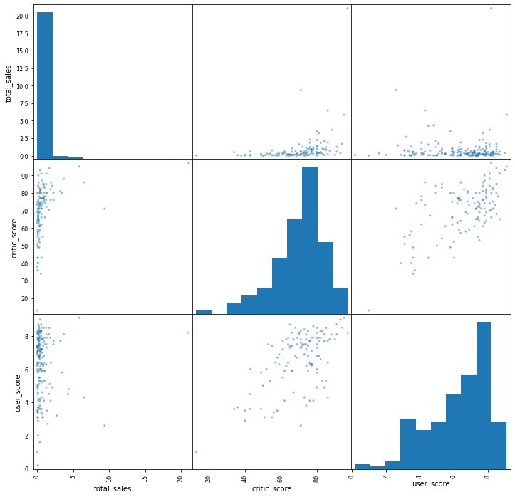

```python
pd.plotting.scatter_matrix(PS3_sales_crit_and_user_ratings, figsize=(12, 12))
```

```python
PS3_sales_crit_and_user_ratings.corr()
```

|  | total_sales | critic_score | user_score |
| --- | --- | --- | --- |
| total_sales | 1.000000 | 0.334285 | 0.002394 |
| critic_score | 0.334285 | 1.000000 | 0.599920 |
| user_score | 0.002394 | 0.599920 | 1.000000 |

```python
XOne_sales_crit_and_user_ratings = XOne_actual_data.loc[:,['total_sales', 'critic_score', 'user_score']]
XOne_sales_crit_and_user_ratings.head()
```

|  | total_sales | critic_score | user_score |
| --- | --- | --- | --- |
| 99 | 7.39 | NaN | NaN |
| 165 | 5.47 | 97.0 | 7.9 |
| 179 | 5.26 | 81.0 | 5.4 |
| 242 | 4.49 | 84.0 | 6.4 |
| 270 | 4.22 | 88.0 | 6.2 |

```
array([[<AxesSubplot:xlabel='total_sales', ylabel='total_sales'>,
        <AxesSubplot:xlabel='critic_score', ylabel='total_sales'>,
        <AxesSubplot:xlabel='user_score', ylabel='total_sales'>],
       [<AxesSubplot:xlabel='total_sales', ylabel='critic_score'>,
        <AxesSubplot:xlabel='critic_score', ylabel='critic_score'>,
        <AxesSubplot:xlabel='user_score', ylabel='critic_score'>],
       [<AxesSubplot:xlabel='total_sales', ylabel='user_score'>,
        <AxesSubplot:xlabel='critic_score', ylabel='user_score'>,
        <AxesSubplot:xlabel='user_score', ylabel='user_score'>]],
      dtype=object)
```

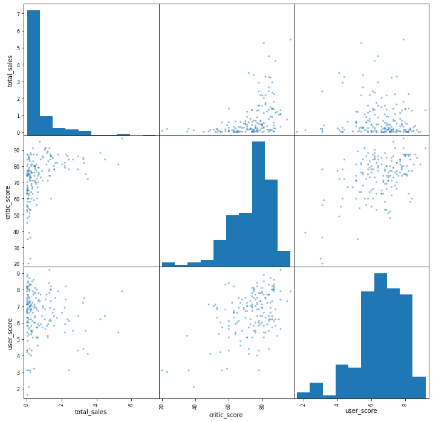

```python
pd.plotting.scatter_matrix(XOne_sales_crit_and_user_ratings, figsize=(12, 12))
```

```python
XOne_sales_crit_and_user_ratings.corr()
```

|  | total_sales | critic_score | user_score |
| --- | --- | --- | --- |
| total_sales | 1.000000 | 0.416998 | -0.068925 |
| critic_score | 0.416998 | 1.000000 | 0.472462 |
| user_score | -0.068925 | 0.472462 | 1.000000 |

```python
_3DS_sales_crit_and_user_ratings = _3DS_actual_data.loc[:,['total_sales', 'critic_score', 'user_score']]
_3DS_sales_crit_and_user_ratings.head()
```

|  | total_sales | critic_score | user_score |
| --- | --- | --- | --- |
| 33 | 14.60 | NaN | NaN |
| 47 | 11.68 | NaN | NaN |
| 96 | 7.55 | NaN | NaN |
| 108 | 7.14 | NaN | NaN |
| 184 | 5.22 | NaN | NaN |

```
array([[<AxesSubplot:xlabel='total_sales', ylabel='total_sales'>,
        <AxesSubplot:xlabel='critic_score', ylabel='total_sales'>,
        <AxesSubplot:xlabel='user_score', ylabel='total_sales'>],
       [<AxesSubplot:xlabel='total_sales', ylabel='critic_score'>,
        <AxesSubplot:xlabel='critic_score', ylabel='critic_score'>,
        <AxesSubplot:xlabel='user_score', ylabel='critic_score'>],
       [<AxesSubplot:xlabel='total_sales', ylabel='user_score'>,
        <AxesSubplot:xlabel='critic_score', ylabel='user_score'>,
        <AxesSubplot:xlabel='user_score', ylabel='user_score'>]],
      dtype=object)
```

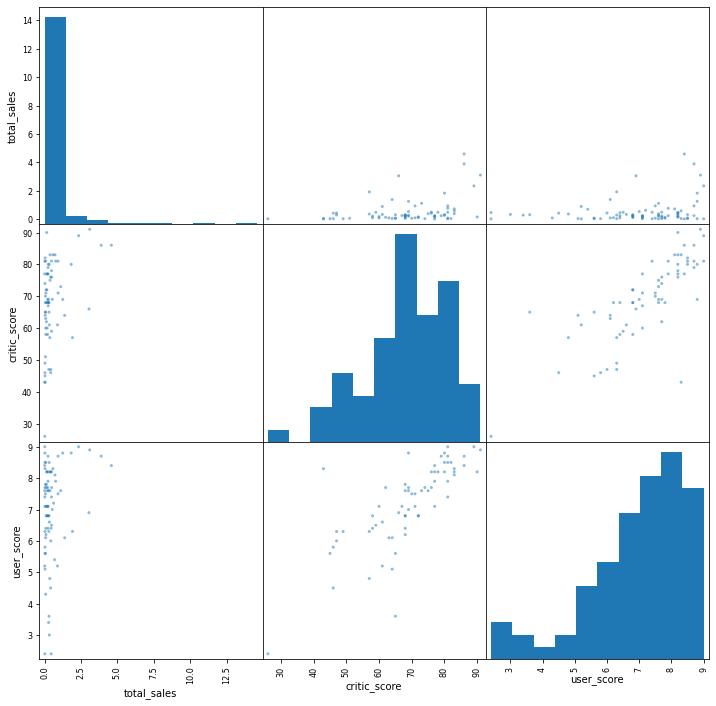

```python
pd.plotting.scatter_matrix(_3DS_sales_crit_and_user_ratings, figsize=(12, 12))
```

```python
_3DS_sales_crit_and_user_ratings.corr()
```

|  | total_sales | critic_score | user_score |
| --- | --- | --- | --- |
| total_sales | 1.000000 | 0.357057 | 0.241504 |
| critic_score | 0.357057 | 1.000000 | 0.769536 |
| user_score | 0.241504 | 0.769536 | 1.000000 |

```python
X360_sales_crit_and_user_ratings = X360_actual_data.loc[:,['total_sales', 'critic_score', 'user_score']]
X360_sales_crit_and_user_ratings.head()
```

|  | total_sales | critic_score | user_score |
| --- | --- | --- | --- |
| 23 | 16.27 | 97.0 | 8.1 |
| 60 | 10.24 | 73.0 | 2.6 |
| 72 | 9.18 | NaN | NaN |
| 263 | 4.28 | NaN | 4.9 |
| 271 | 4.22 | 84.0 | 4.2 |

```
array([[<AxesSubplot:xlabel='total_sales', ylabel='total_sales'>,
        <AxesSubplot:xlabel='critic_score', ylabel='total_sales'>,
        <AxesSubplot:xlabel='user_score', ylabel='total_sales'>],
       [<AxesSubplot:xlabel='total_sales', ylabel='critic_score'>,
        <AxesSubplot:xlabel='critic_score', ylabel='critic_score'>,
        <AxesSubplot:xlabel='user_score', ylabel='critic_score'>],
       [<AxesSubplot:xlabel='total_sales', ylabel='user_score'>,
        <AxesSubplot:xlabel='critic_score', ylabel='user_score'>,
        <AxesSubplot:xlabel='user_score', ylabel='user_score'>]],
      dtype=object)
```

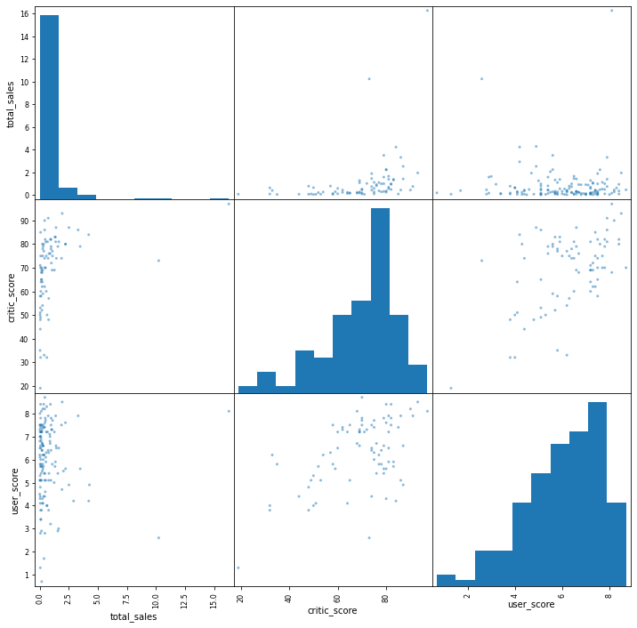

```python
pd.plotting.scatter_matrix(X360_sales_crit_and_user_ratings, figsize=(12, 12))
```

```python
X360_sales_crit_and_user_ratings.corr()
```

|  | total_sales | critic_score | user_score |
| --- | --- | --- | --- |
| total_sales | 1.000000 | 0.350345 | -0.011742 |
| critic_score | 0.350345 | 1.000000 | 0.520946 |
| user_score | -0.011742 | 0.520946 | 1.000000 |

**Вывод:** Для платформы PS4 есть прямая корреляция между продажами и рейтингом критиков. Можно предположить, что важным критерием для платформы является качество игры. Между рейтингом критиков и пользователей еще более сильная корреляция. Исходя из анализа, видим, что рейтинг игры влияет на мнение игроков. То есть, чем выше ценит игру критик, тем выше оценит ее игрок. Также есть незначительная обратная корреляция между продажами и рейтингом пользователей, значит эти величины не зависят друг от друга. Платформы PS3, XOne и X360 имеют похожие связи, как и у PS4. Можно выделить платфому 3DS, чьи продажи зависят напрямую, хоть и не сильно от рейтинга игроков. Можно предположить, что в данном направлении компания лучше ведет работу по составлению рейтинга для игр и системы отзывов для игроков.

**Вопрос 7.** *Посмотрите на общее распределение игр по жанрам. Что можно сказать о самых прибыльных жанрах? Выделяются ли жанры с высокими и низкими продажами?*

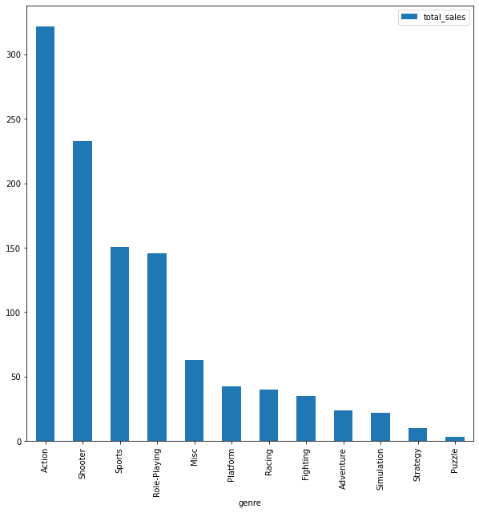

```python
genre_pvt = actual_data.pivot_table(index='genre', values='total_sales', aggfunc='sum')
genre_pvt.sort_values('total_sales', ascending=False).plot(kind='bar', figsize=(10,10))
```

**Вывод:** Самые прибыльные жанры: Action, Shooter, Sports и Role-Playing. Игрокам больше нравятся активные жанры, основаннные на разнообразии действий ("Стрелялки" и "Боевики"), а также ролевые игры, где участвует много игроков. Игры логических жанров в сравнении с играми жанра action практически вообще не пользуются спросом.

# Шаг 5. Составьте портрет пользователя каждого региона

**Вопрос 1.** *Определите для пользователя каждого региона (NA, EU, JP):*

*- Самые популярные платформы (топ-5). Опишите различия в долях продаж.*

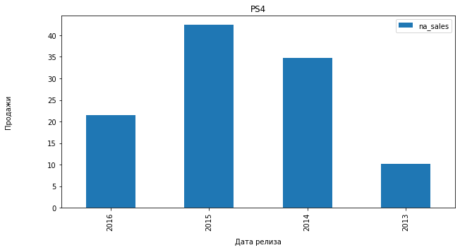

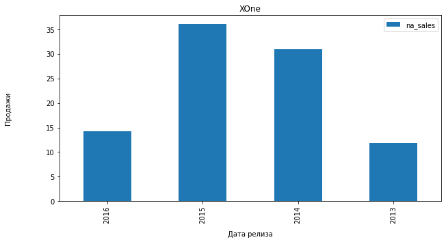

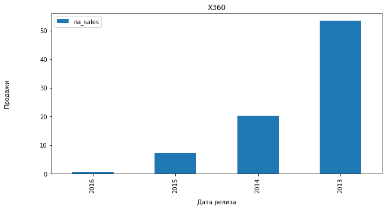

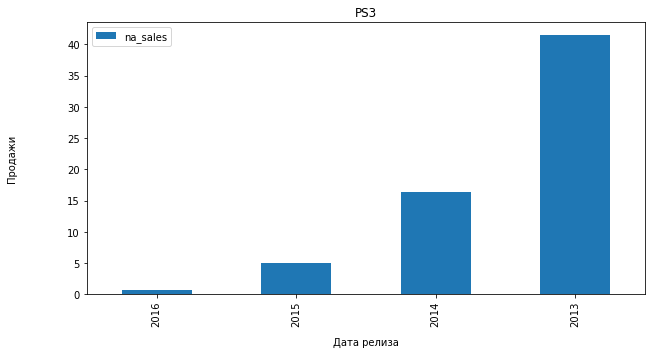

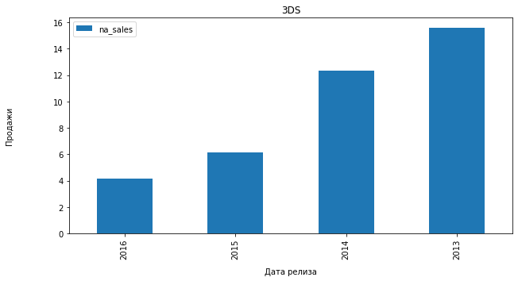

```python
top_5_na_sales = actual_data.query('na_sales > 0').groupby(['platform'],
            as_index = False)['na_sales'].sum().sort_values('na_sales',
                                ascending = False).head(5)['platform'].tolist()

for name in top_5_na_sales:
    actual_data.query('platform == @name').pivot_table(index = 'year_of_release',
                        values = ['na_sales'], aggfunc = 'sum').sort_values('year_of_release',
                                                    ascending = False).plot(kind='bar',figsize = (10, 5), title = name)

    plt.xlabel('Дата релиза', labelpad = 10)
    plt.ylabel('Продажи', labelpad = 50)
    plt.legend()
```

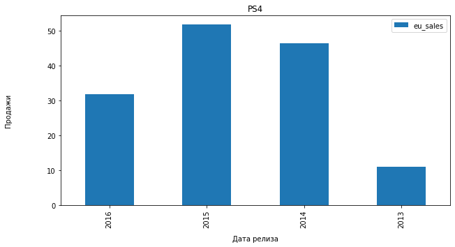

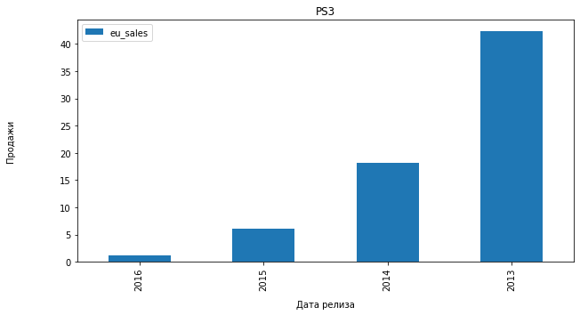

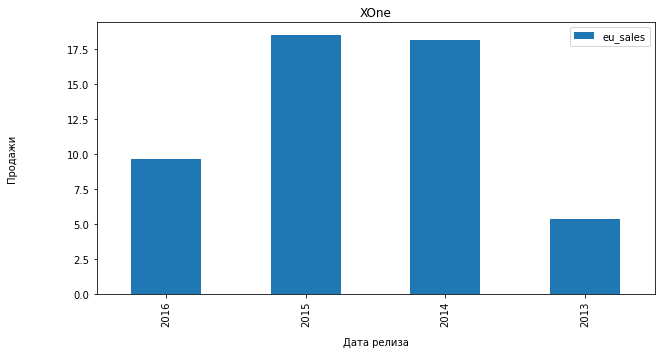

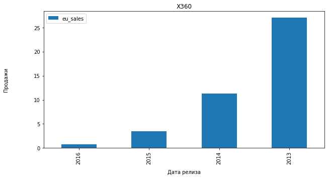

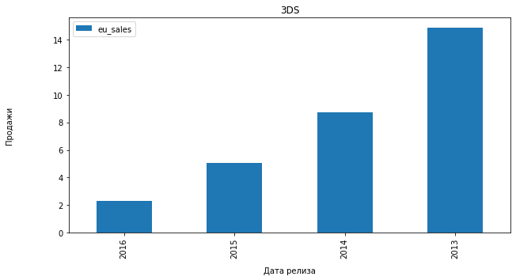

```python
top_5_eu_sales = actual_data.query('eu_sales > 0').groupby(['platform'],
            as_index = False)['eu_sales'].sum().sort_values('eu_sales',
                                ascending = False).head(5)['platform'].tolist()

for name in top_5_eu_sales:
    actual_data.query('platform == @name').pivot_table(index = 'year_of_release',
                        values = ['eu_sales'], aggfunc = 'sum').sort_values('year_of_release',
                                                    ascending = False).plot(kind='bar',figsize = (10, 5), title = name)

    plt.xlabel('Дата релиза', labelpad = 10)
    plt.ylabel('Продажи', labelpad = 50)
    plt.legend()
```